# Data 621 Homework 1: Moneyball

Tommy Jenkins, Violeta Stoyanova, Todd Weigel, Peter Kowalchuk, Eleanor R-Secoquian

September, 2019

# 1 OVERVIEW

In this homework assignment, we will explore, analyze and model a data set containing approximately 2200 records. Each record represents a professional baseball team from the years 1871 to 2006 inclusive. Each record has the performance of the team for the given year, with all of the statistics adjusted to match the performance of a 162 game season.

## 1.1 Objective:

To build a multiple linear regression model on the training data to predict the number of wins for the team. We can only use the variables provided (or variables that we will derive from the variables provided).

# 2 DATA EXPLORATION

## 2.1 Data Summary

The dataset consists of two data files: training and evaluation. The training dataset contains 17 columns, while the evaluation dataset contains 16. The evaluation dataset is missing column TARGET_WINS. We will start by exploring the training data set since it will be the one used to generate the regression model.

First we see that all data is numeric.

An important aspect of any dataset is to determine how much, if any, data is missing. We look at all the variables to see which if any have missing data. We look at the basic descriptive statistics as well as the missing data and their percentages:

|  | vars | n | mean | sd | median | trimmed | mad | min | max | range | skew | kurtosis | se | na_count | na_count_perc |
| --- | --- | --- | --- | --- | --- | --- | --- | --- | --- | --- | --- | --- | --- | --- | --- |
| TARGET_WINS | 2 | 191 | 80.92670 | 12.115013 | 82 | 81.11765 | 13.3434 | 43 | 116 | 73 | -0.1698314 | -0.2952783 | 0.8766116 | 0 | 0.0 |
| TEAM_BATTING_H | 3 | 191 | 1478.62827 | 76.147869 | 1477 | 1477.42484 | 74.1300 | 1308 | 1667 | 359 | 0.1302702 | -0.3710350 | 5.5098664 | 0 | 0.0 |
| TEAM_BATTING_2B | 4 | 191 | 297.19895 | 26.329335 | 296 | 296.62745 | 25.2042 | 201 | 373 | 172 | 0.0915189 | 0.4778716 | 1.9051238 | 0 | 0.0 |
| TEAM_BATTING_3B | 5 | 191 | 30.74346 | 9.043878 | 29 | 30.13072 | 8.8956 | 12 | 61 | 49 | 0.7007420 | 0.7446217 | 0.6543921 | 0 | 0.0 |
| TEAM_BATTING_HR | 6 | 191 | 178.05236 | 32.413243 | 175 | 176.81046 | 35.5824 | 116 | 260 | 144 | 0.2980673 | -0.7172373 | 2.3453399 | 0 | 0.0 |
| TEAM_BATTING_BB | 7 | 191 | 543.31937 | 74.842133 | 535 | 541.31373 | 74.1300 | 365 | 775 | 410 | 0.3115199 | -0.1474175 | 5.4153867 | 0 | 0.0 |
| TEAM_BATTING_SO | 8 | 191 | 1051.02618 | 104.156382 | 1050 | 1046.95425 | 97.8516 | 805 | 1399 | 594 | 0.3985050 | 0.3955105 | 7.5364913 | 102 | 4.5 |
| TEAM_BASERUN_SB | 9 | 191 | 90.90576 | 29.916401 | 87 | 89.06536 | 29.6520 | 31 | 177 | 146 | 0.5553966 | -0.1414909 | 2.1646748 | 131 | 5.8 |
| TEAM_BASERUN_CS | 10 | 191 | 39.94241 | 11.898334 | 38 | 39.49020 | 11.8608 | 12 | 74 | 62 | 0.3468509 | 0.0006392 | 0.8609332 | 772 | 33.9 |
| TEAM_BATTING_HBP | 11 | 191 | 59.35602 | 12.967123 | 58 | 58.86275 | 11.8608 | 29 | 95 | 66 | 0.3185754 | -0.1119828 | 0.9382681 | 2085 | 91.6 |
| TEAM_PITCHING_H | 12 | 191 | 1479.70157 | 75.788625 | 1480 | 1478.50327 | 72.6474 | 1312 | 1667 | 355 | 0.1279056 | -0.3894781 | 5.4838725 | 0 | 0.0 |
| TEAM_PITCHING_HR | 13 | 191 | 178.17801 | 32.391678 | 175 | 176.93464 | 35.5824 | 116 | 260 | 144 | 0.2989191 | -0.7190905 | 2.3437795 | 0 | 0.0 |
| TEAM_PITCHING_BB | 14 | 191 | 543.71728 | 74.916681 | 537 | 541.74510 | 72.6474 | 367 | 775 | 408 | 0.3144366 | -0.1338563 | 5.4207808 | 0 | 0.0 |
| TEAM_PITCHING_SO | 15 | 191 | 1051.81675 | 104.347208 | 1052 | 1047.80392 | 97.8516 | 805 | 1399 | 594 | 0.3945586 | 0.3903991 | 7.5502990 | 102 | 4.5 |
| TEAM_FIELDING_E | 16 | 191 | 107.05236 | 16.632162 | 106 | 106.58170 | 17.7912 | 65 | 145 | 80 | 0.1780432 | -0.3567367 | 1.2034610 | 0 | 0.0 |
| TEAM_FIELDING_DP | 17 | 191 | 152.33508 | 17.611682 | 152 | 152.04575 | 19.2738 | 113 | 204 | 91 | 0.2164822 | -0.2115741 | 1.2743366 | 286 | 12.6 |

```
##            INDEX      TARGET_WINS   TEAM_BATTING_H  TEAM_BATTING_2B
##              0.0              0.0              0.0              0.0
##  TEAM_BATTING_3B  TEAM_BATTING_HR  TEAM_BATTING_BB  TEAM_BATTING_SO
##              0.0              0.0              0.0              4.5
##  TEAM_BASERUN_SB  TEAM_BASERUN_CS TEAM_BATTING_HBP  TEAM_PITCHING_H
##              5.8             33.9             91.6              0.0
## TEAM_PITCHING_HR TEAM_PITCHING_BB TEAM_PITCHING_SO  TEAM_FIELDING_E
##              0.0              0.0              4.5              0.0
## TEAM_FIELDING_DP
##             12.6
```

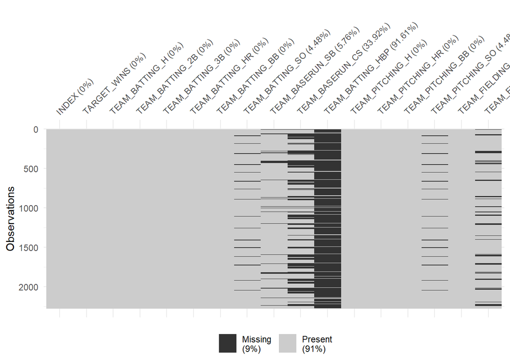

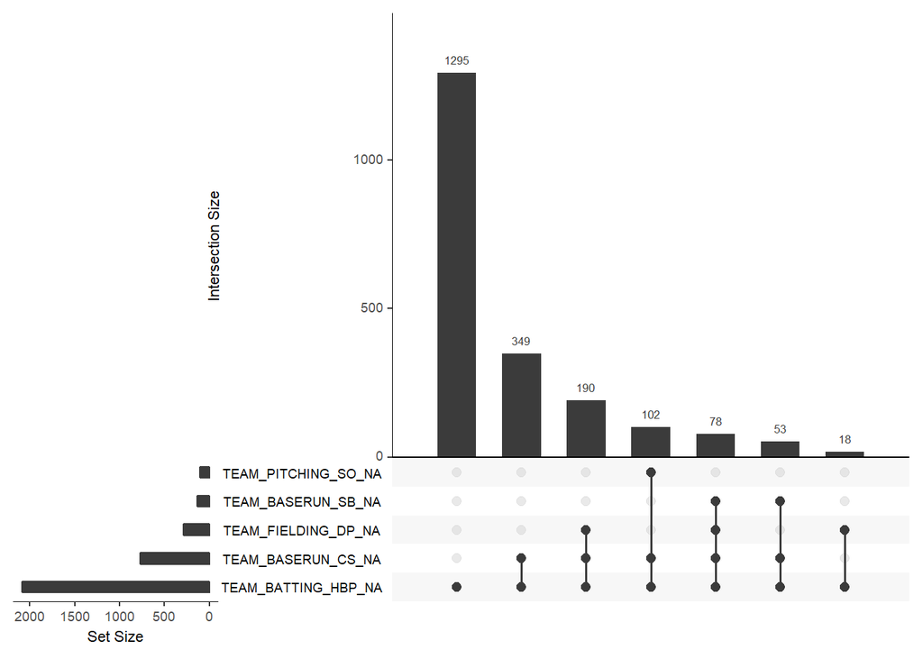

## 2.2 Missing and Invalid Data

From this result we can see how several variables have a number of missing values. The maximum number of missing values was 2085 in the TEAM_BATTING_HBP variable. This is a significant amount of missing data representing 91.6% of that data.

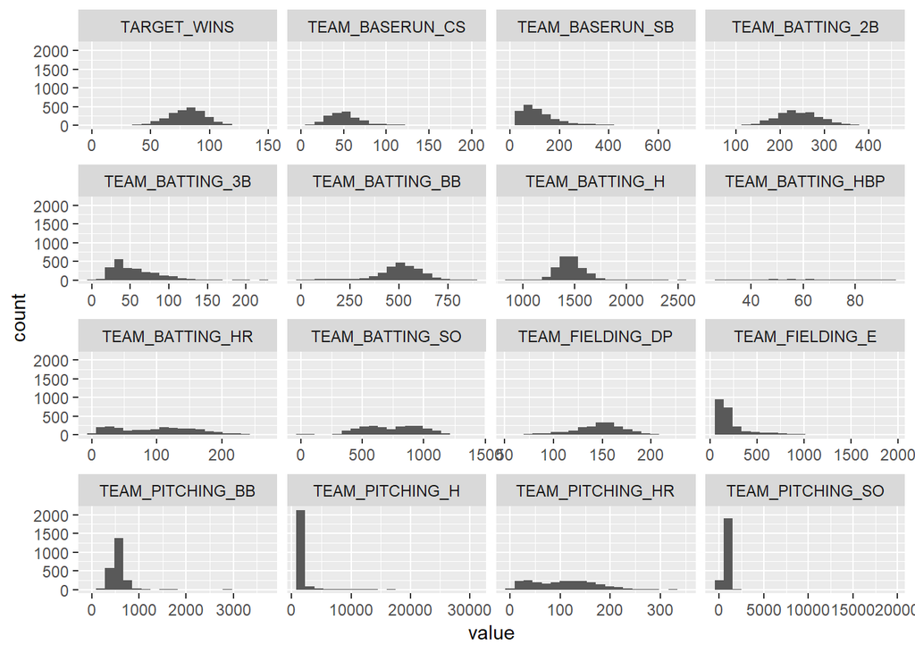

**TEAM_PITCHING_H**

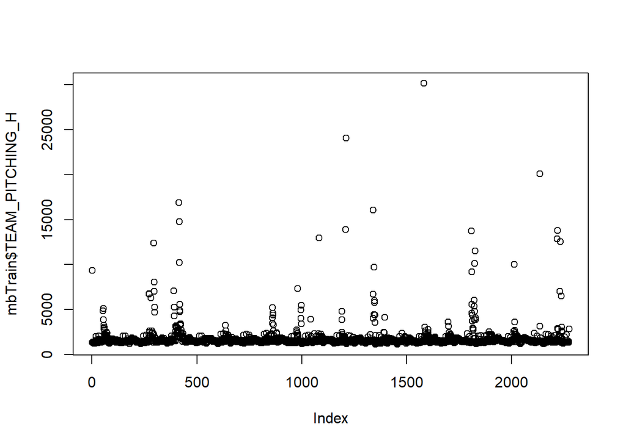

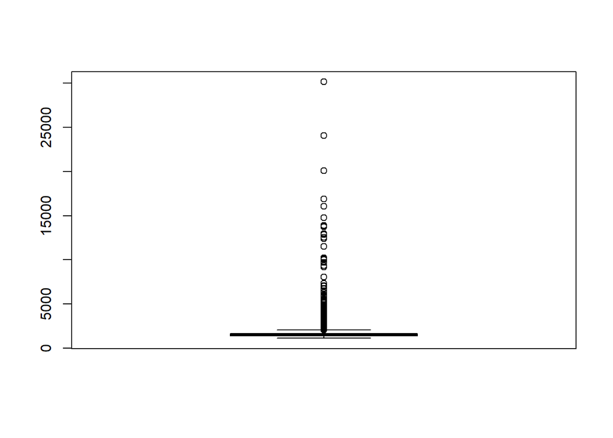

```
##    Min. 1st Qu.  Median    Mean 3rd Qu.    Max.
##    1137    1419    1518    1779    1682   30132
```

```
##    Min. 1st Qu.  Median    Mean 3rd Qu.    Max.
##     891    1383    1454    1469    1537    2554
```

**TEAM_PITCHING_SO**

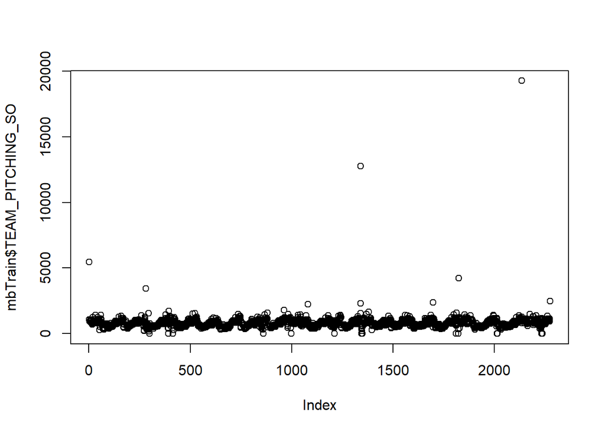

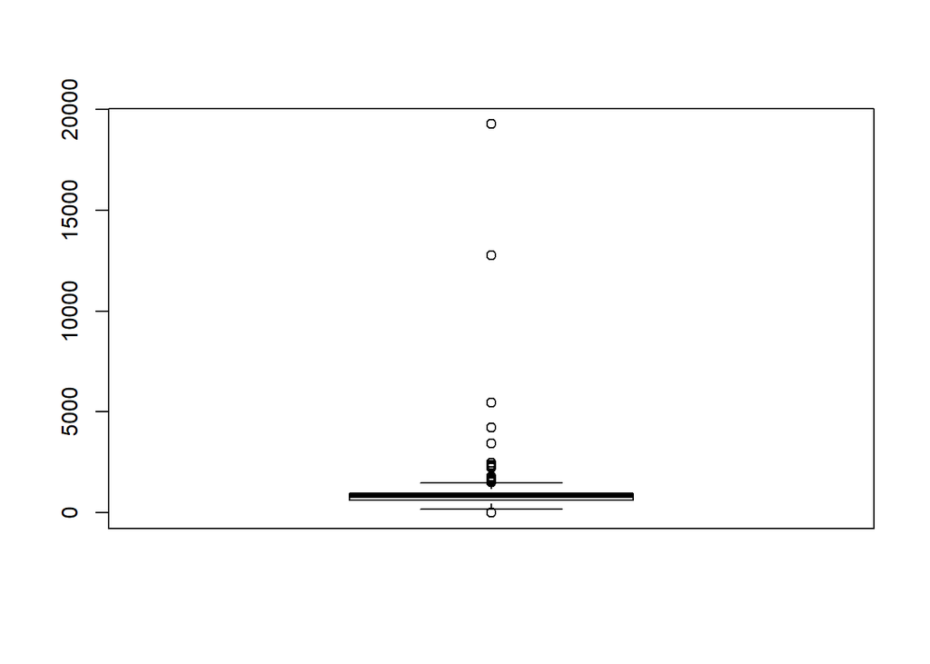

```
##    Min. 1st Qu.  Median    Mean 3rd Qu.    Max.    NA's
##     0.0   615.0   813.5   817.7   968.0 19278.0     102
```

```
##    Min. 1st Qu.  Median    Mean 3rd Qu.    Max.    NA's
##     0.0   548.0   750.0   735.6   930.0  1399.0     102
```

**TEAM_PITCHING_BB**

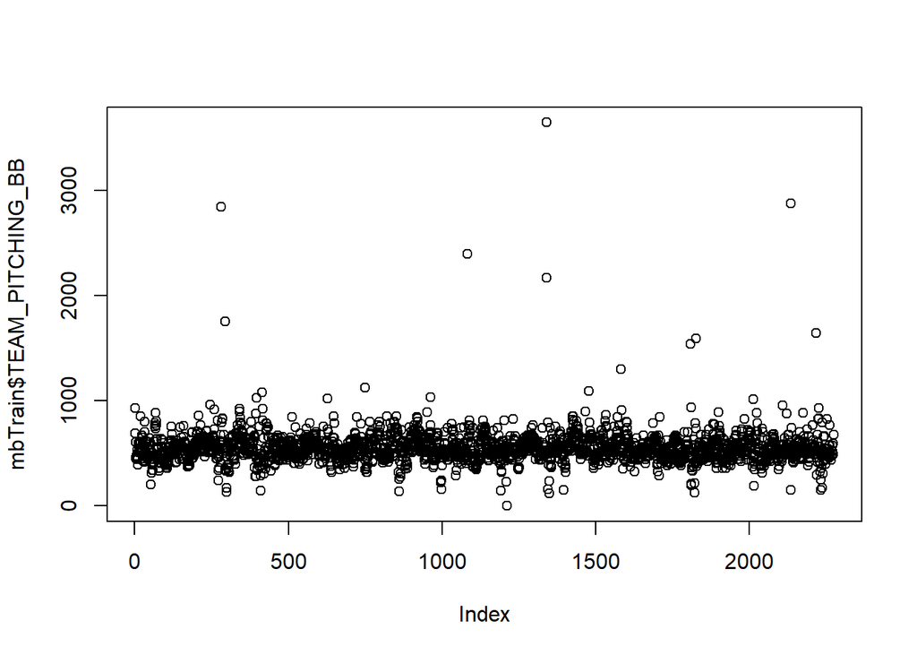

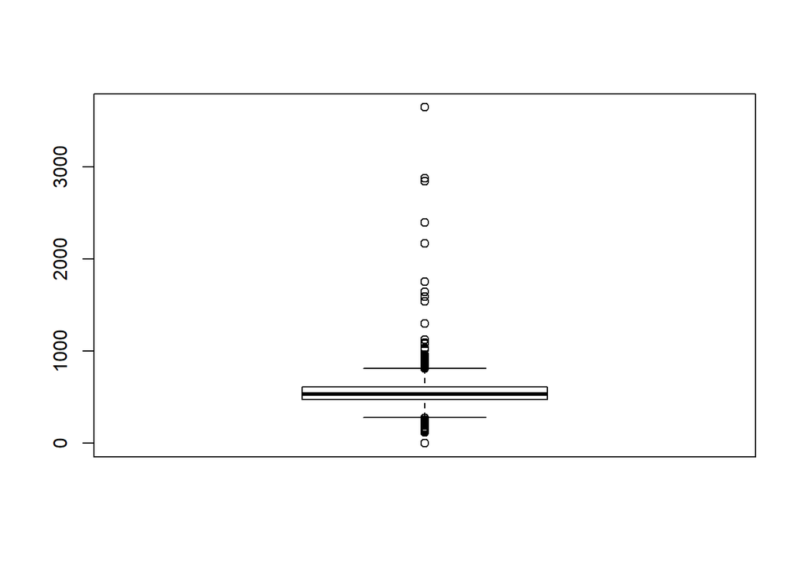

```
##    Min. 1st Qu.  Median    Mean 3rd Qu.    Max.
##     0.0   476.0   536.5   553.0   611.0  3645.0
```

```
##    Min. 1st Qu.  Median    Mean 3rd Qu.    Max.
##     0.0   451.0   512.0   501.6   580.0   878.0
```

We see that or batting the maximum is 878, much lower than 3645. As before as a sanity check of the distribution of the batting variable, we now see the mean and median much closer together with a spread of only 10.4.

**TEAM_FIELDING_E**

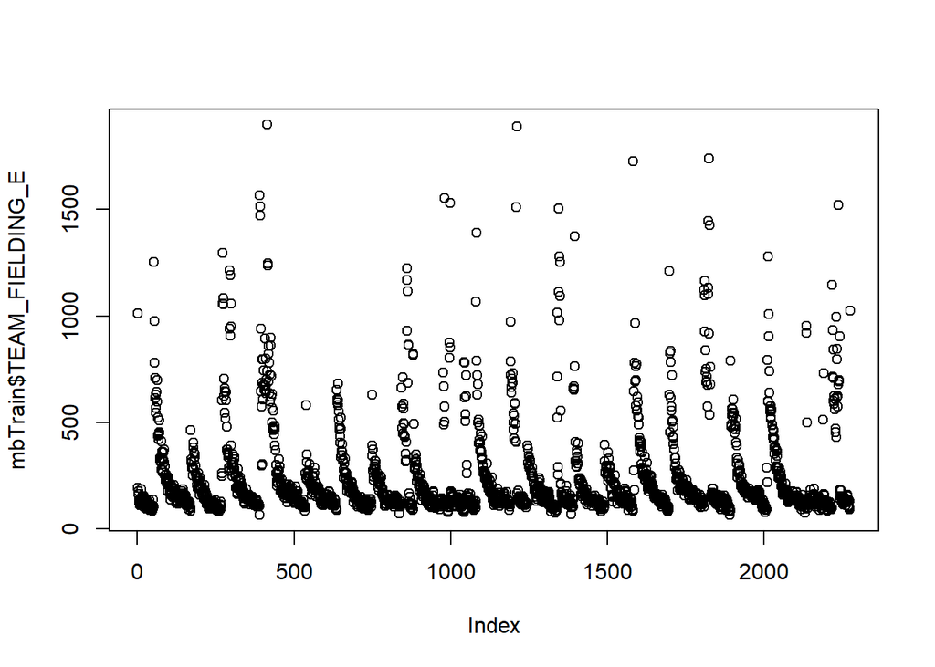

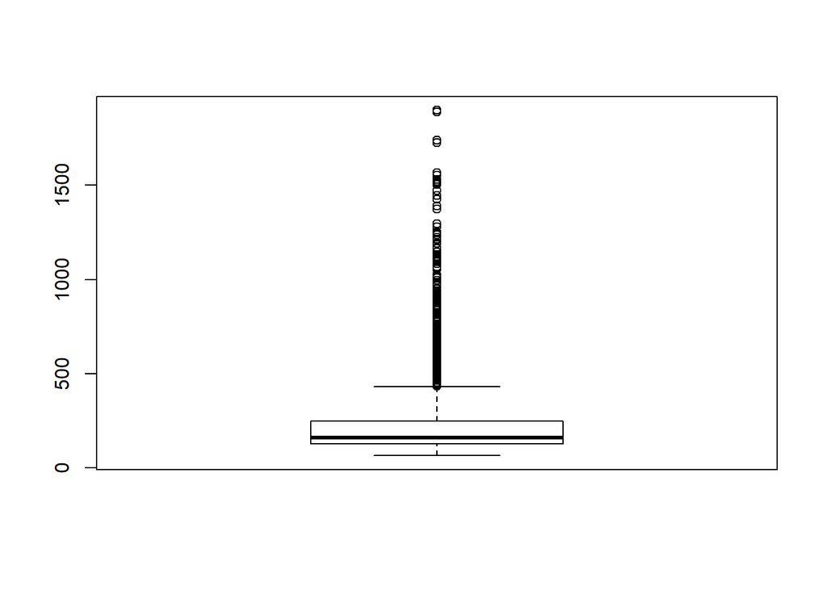

```
##    Min. 1st Qu.  Median    Mean 3rd Qu.    Max.
##    65.0   127.0   159.0   246.5   249.2  1898.0
```

Again looking at the maximum we find it is unreasonably high at 1898, which again is substantially far from the median of 159.

## 2.3 Correlation Plot

Looking at correlation of variables to number of wins provides some interesting data. We find some correlations that make sense from what might assume with subject knowledge of base, e.g., the number of hits and number of variables both have significant positive correlation with Wins and other statistics like stolen bases, while still positive, are not so strongly related. What is surprising though, are the pitching statistics. We would assume that a team that allowed the opposing team more hits, would lose more games (and win less), but that is not what the data shows us. Perhaps there are outliers swaying the correlation.

Regardless, we can use some of these correlations to drive initial models later, in terms of likely fields to choose for an effective model.

```
##      TARGET_WINS TEAM_BATTING_H TEAM_BATTING_2B TEAM_BATTING_3B
## [1,]           1      0.4699467        0.312984      -0.1243459
##      TEAM_BATTING_HR TEAM_BATTING_BB TEAM_BATTING_SO TEAM_BASERUN_SB
## [1,]       0.4224168       0.4686879      -0.2288927      0.01483639
##      TEAM_BASERUN_CS TEAM_BATTING_HBP TEAM_PITCHING_H TEAM_PITCHING_HR
## [1,]       -0.178756       0.07350424       0.4712343        0.4224668
##      TEAM_PITCHING_BB TEAM_PITCHING_SO TEAM_FIELDING_E TEAM_FIELDING_DP
## [1,]        0.4683988       -0.2293648       -0.386688        -0.195866
```

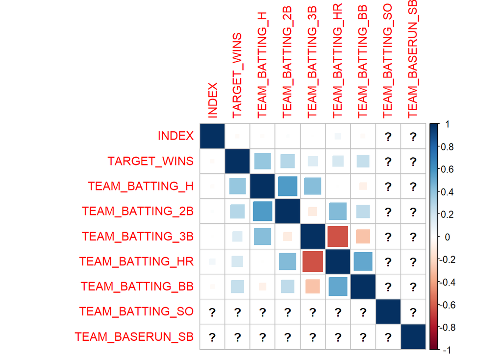

# 3 DATA PREPARATION

## 3.1 Variable Creation / Removal

First task under data preparation will be to eliminate all missing data. In the Data Exploration section we found one variable, TEAM_BATTING_HBP with an exceptionaly high percentage of missing data, so we commence by eliminating this variable. We also removed the “INDEX” column as that is not used.

Next task is to handle missing data in the other variables. Here, because the percentages of missing data are lower, we can replace missing data with the median. We prefer replacing with median instead of mean because the latter is more sensitive to outliers. So we get a clean dataset without missing values.

Note, we also consider zeros to be missing data. Since each row is a season of data for a given baseball team, it would be extraordinarily unlikely that any of these statistics would have zero as an actual value. Therefore we are assuming zero is another indicator of missing value and we will transform them into a median value.

In the exploratory phase we also identified several variables with outliers. Outliers will be substituted with median. Again we choose median becouse it is less influenced by these outliers. What cut-off to use to tag an outlier reading could be a 3 standard deviation from the mean, or 1.5 time the inter quartile range, but in this case because these variables have reciprocals as seen in the exploratory phase, we will use the maximum reading of those variables.

**TEAM_PITCHING_H**

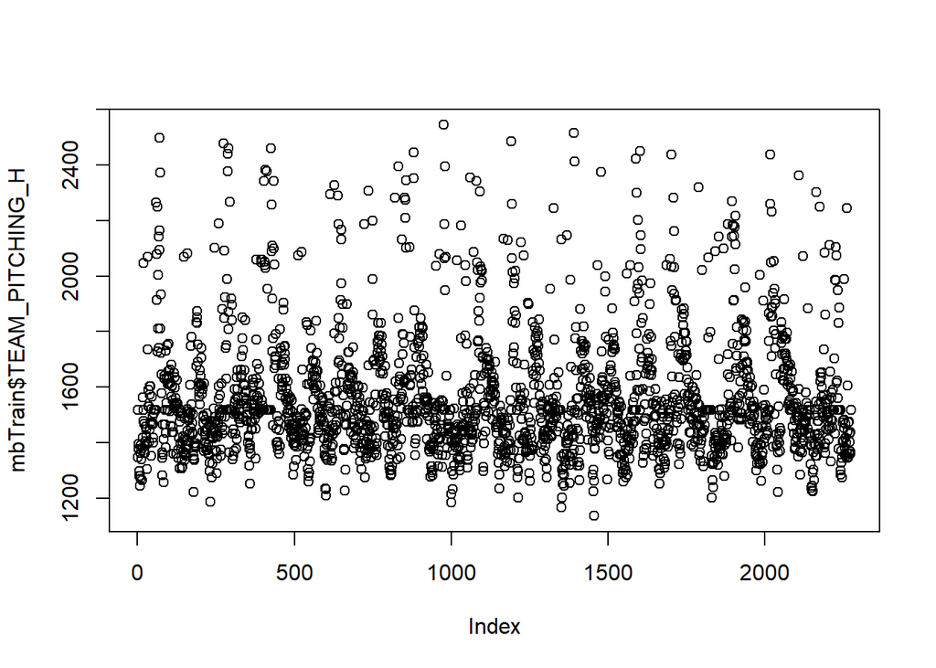

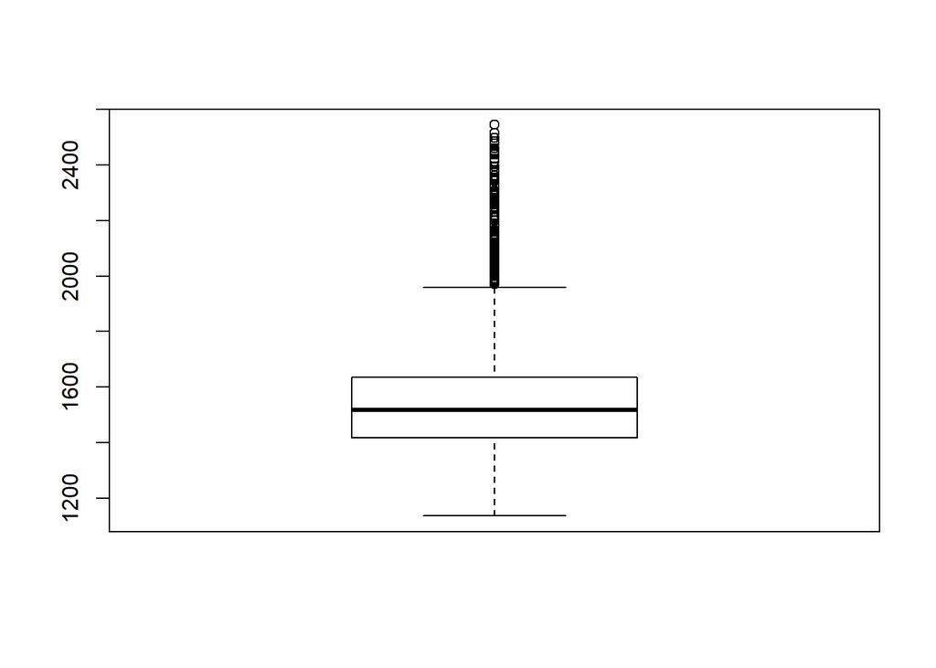

```
##    Min. 1st Qu.  Median    Mean 3rd Qu.    Max.
##    1137    1419    1518    1562    1636    2544
```

From the summary we now see that the maximum is 2544, which is a much more reasonable number. We can also see a wide spread between mean and median of 44, indicating a more normal distribution than before.

**TEAM_PITCHING_SO**

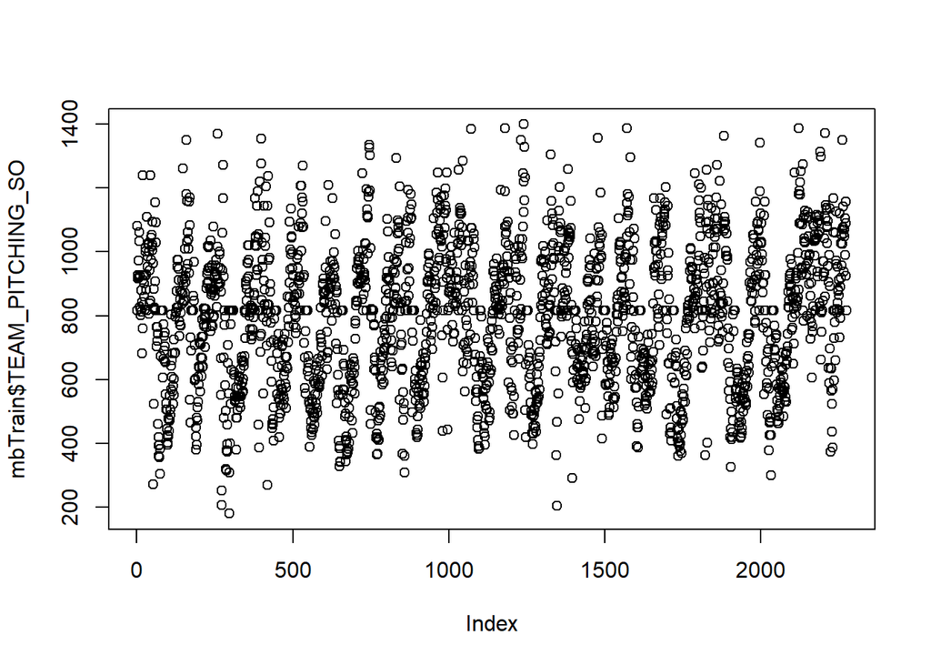

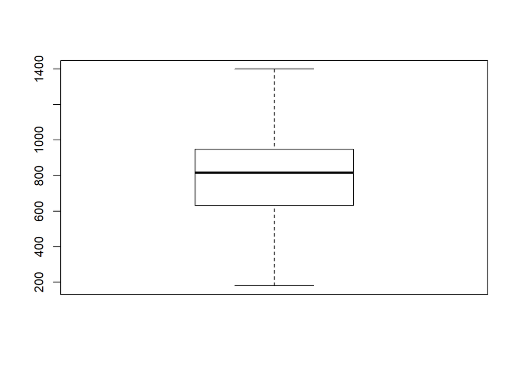

```
##    Min. 1st Qu.  Median    Mean 3rd Qu.    Max.
##   181.0   633.0   816.0   796.8   948.2  1399.0
```

From the summary we now see that the maximum is 1399, which is a much more reasonable number. We can also see a wide spread between mean and median of -19, indicating a more normal distribution than before.

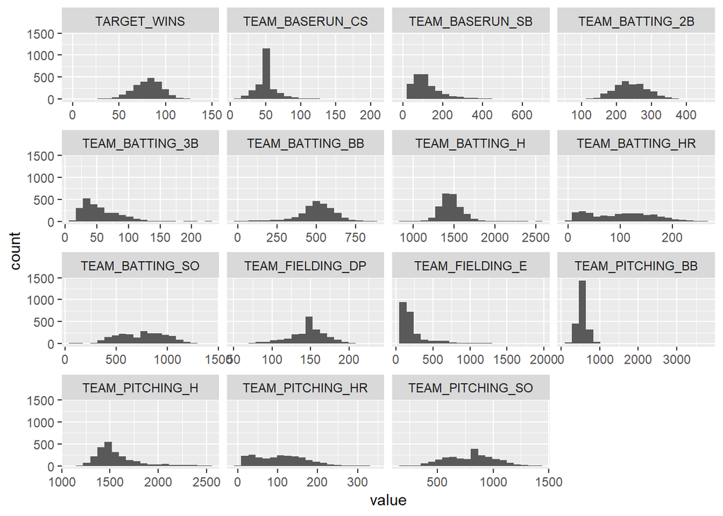

**New Variables**

With a clean dataset, we can now start looking at what predictor variables can be combined and what new statistics can be derived.

**Batting Hit Singles**

On the batting side we can start by adding a variable for single hits since the dataset has a variable for all 4 kinds of hits.

TEAM_BATTING_HS = TEAM_BATTING_H - (TEAM_BATTING_2B + TEAM_BATTING_3B + TEAM_BATTING_HR)

TEAM_BATTING_HS Summary

```
##    Min. 1st Qu.  Median    Mean 3rd Qu.    Max.
##     606     990    1050    1072    1129    2112
```

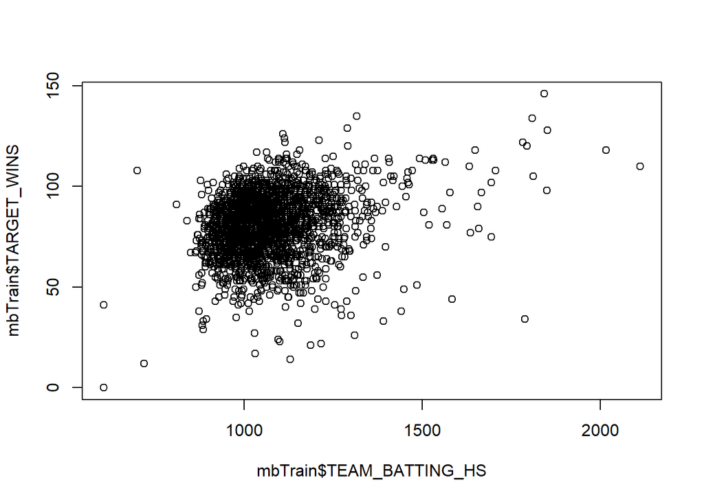

There are other popular baseball statistics which are regularly calculated. The data given is limited, so it won’t be possible to make all these calculations. But we can use the data given to calculate some statistics that resemble some of the common baseball measurements.

The number of times a batter reaches base can be calculated as Times On Base:

**Times On Base**

TOB = Base Hits + Walks + Hits by Pitch TOB = ( TEAM_BATTING_H - TEAM_BATTING_HR ) + TEAM_BATTING_BB + TEAM_BATTING_HBP TOB = TEAM_BATTING_TOB

In our case we do not have TEAM_BATTING_HBP. We deleted this predictor since it didn’t contain enough data, so we will not include this term in calculating TOB.

TEAM_BATTING_TOB Summary:

```
##    Min. 1st Qu.  Median    Mean 3rd Qu.    Max.
##     788    1269    1338    1369    1442    2518
```

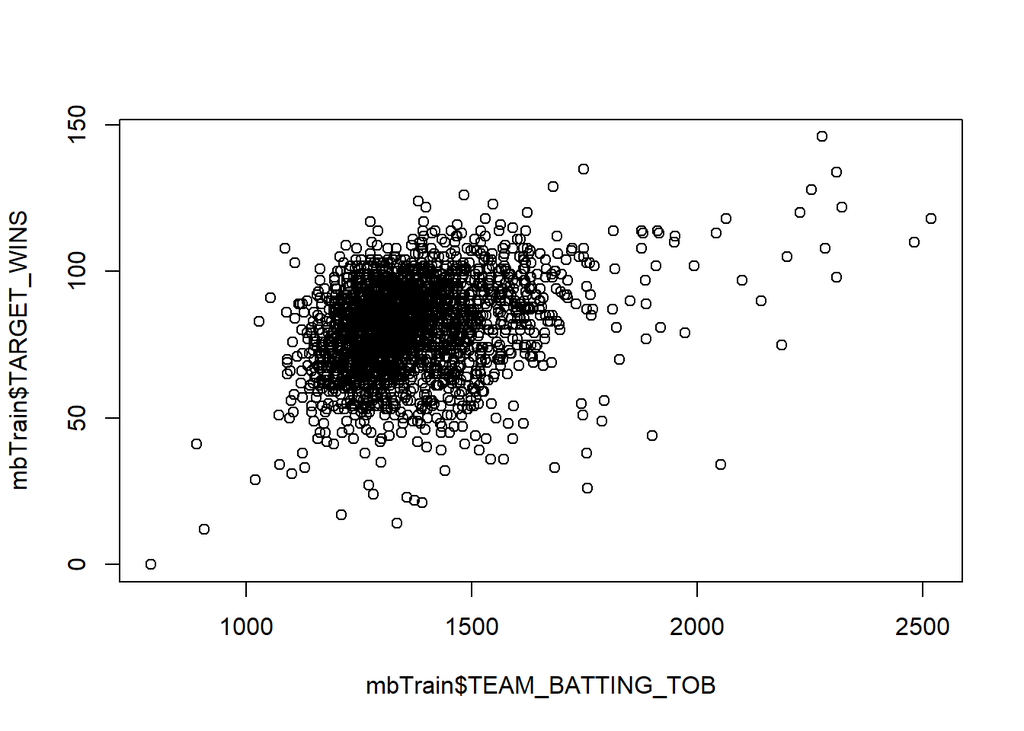

**On Base Percentage**

If we divide this statistic by the times a batter appears on plate, we have a ratio for On Base Percentage. Batter appearances on plate is not a statistic that was given, but we can assumes it would the similar to the number of times a batter produces a hit and the times of strikeouts.

OBP = TOB / ( Base Hits + Walks + Hits by Pitch + Strikeouts ) OBP = TEAM_BATTING_TOB / (( TEAM_BATTING_H - TEAM_BATTING_HR ) + TEAM_BATTING_BB + TEAM_BATTING_HBP + TEAM_BATTING_SO ) OBP = TEAM_BATTING_OBP

Same as before TEAM_BATTING_HBP is missing so we do not include it.

TEAM_BATTING_OBP Summary

```
##    Min. 1st Qu.  Median    Mean 3rd Qu.    Max.
##  0.3801  0.4658  0.5122  0.5287  0.5743  0.9469
```

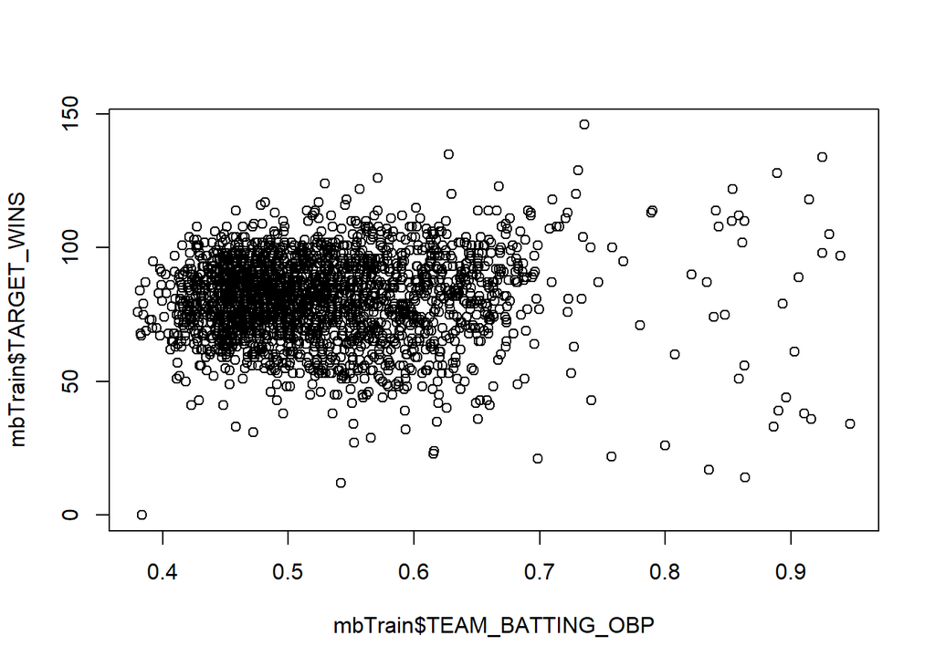

**Batting Average**

This statistics is calculated as the number of batter hits divided by times at bat or on plate. With our dataset we will compute times at bat as the sum of a batters hits and strike out, same as we did on the previous calculated variable since the number of Hits by Pitch is not available:

AVG = Hits / (Hits + Walks + Strikeouts) AVG = TEAM_BATTING_H / ( TEAM_BATTING_H + TEAM_BATTING_BB + TEAM_BATTING_SO ) AVG = TEAM_BATTING_BAVG

TEAM_BATTING_BAVG Summary

```
##    Min. 1st Qu.  Median    Mean 3rd Qu.    Max.
##  0.4131  0.4923  0.5290  0.5464  0.5846  0.9471
```

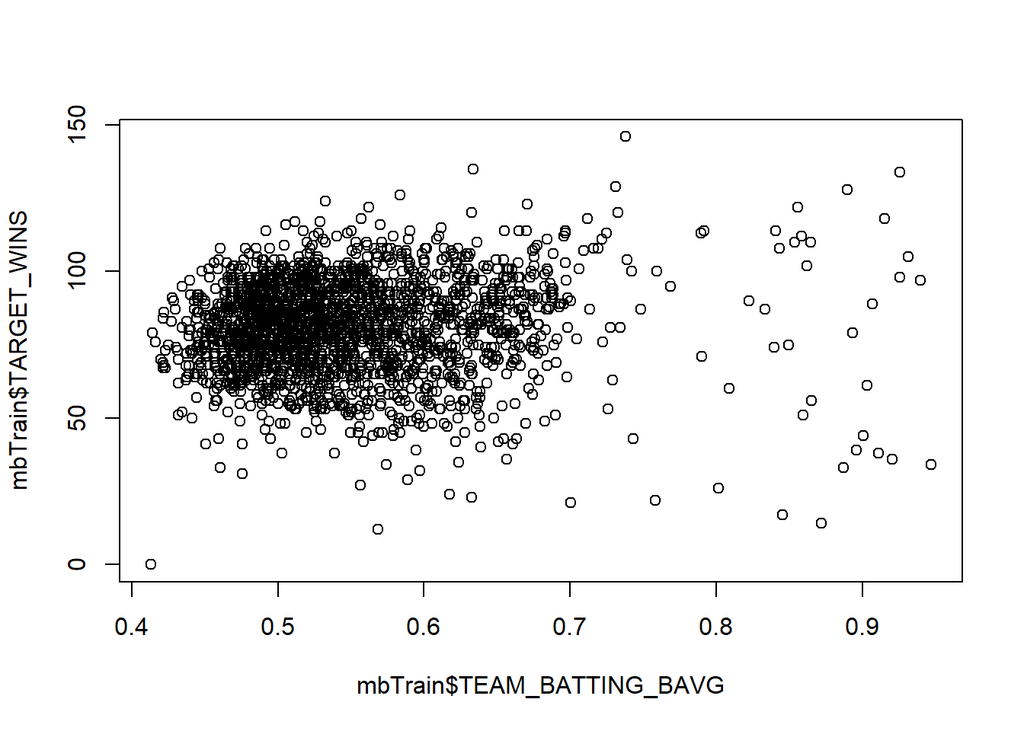

**Slugging Percentage**

A shortcoming of the previous statistic is that it weights any kind of hits equally. To account for the fact that some hits are more beneficial or carry higher weight we can calculate a slugging percentage by multiplying each kind of hit by an increasing number.

SLG = ( Single Hits + 2 * Double Hits + 3 * Tripple Hits + 4 * Home Runs ) / (Hits + Walks + Strikeouts) TEAM_BATTING_SLG = ( ( TEAM_BATTING_H - TEAM_BATTING_2B - TEAM_BATTING_3B - TEAM_BATTING_HR ) + 2 * TEAM_BATTING_2B + 3 * TEAM_BATTING_3B + 4 * TEAM_BATTING_HR ) / ( mbTrain$TEAM_BATTING_H + mbTrain$TEAM_BATTING_BB + mbTrain$TEAM_BATTING_SO )

TEAM_BATTING_SLG Summary

```
##    Min. 1st Qu.  Median    Mean 3rd Qu.    Max.
##  0.5861  0.7288  0.7731  0.7842  0.8291  1.2690
```

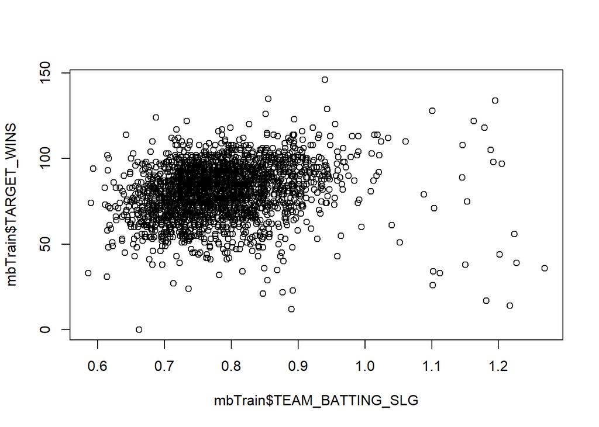

**Strikeout Efficiency**

Measures how successful a pitches is at striking out batters:

PEFF = Strike Outs (Hits + Strike Outs) TEAM_PITCHING_PEFF = TEAM_PITCHING_SO (TEAM_PITCHING_H + TEAM_PITCHING_SO)

TEAM_PITCHING_PEFF Summary

```
##    Min. 1st Qu.  Median    Mean 3rd Qu.    Max.
##  0.1065  0.2813  0.3503  0.3358  0.3944  0.5038
```

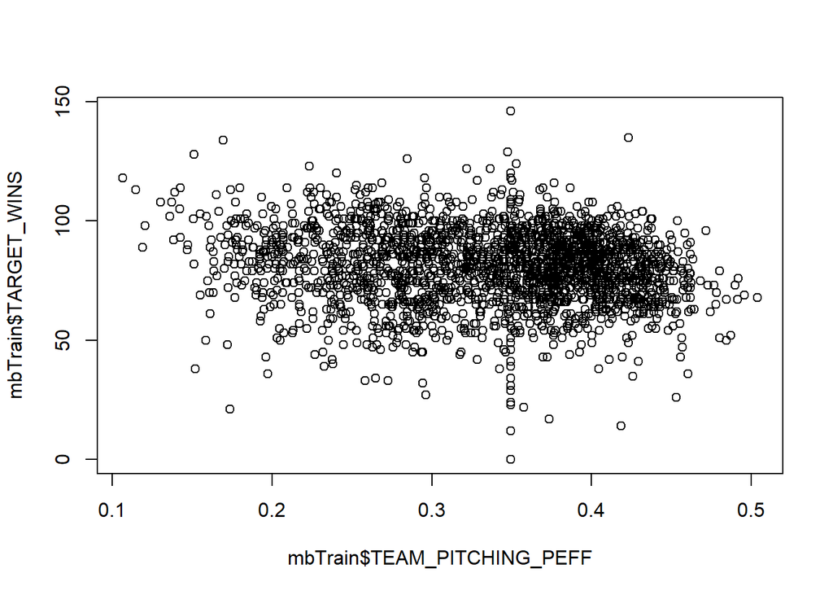

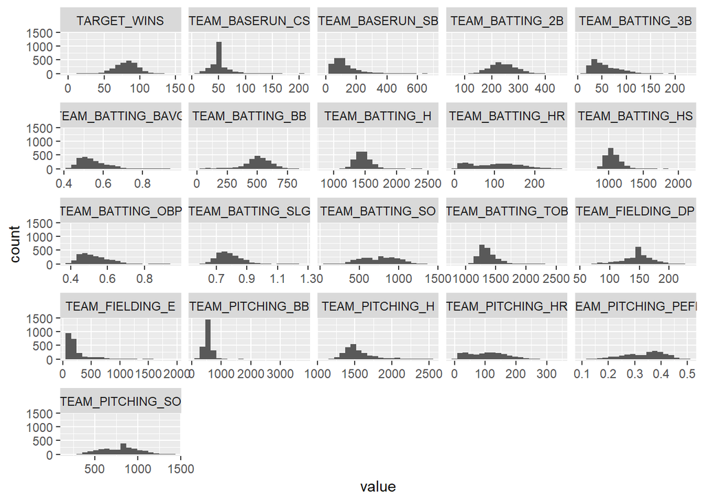

**Training and Test**

Lastly, before we create models, let’s divide data into test and training sets, with 80% for training, 20% for test. This way we have a method to validate our models.

# 4 BUILD MODELS

## 4.1 Batting only model

```
##
## Call:
## lm(formula = TARGET_WINS ~ TEAM_BATTING_H, data = train)
##
## Residuals:
##     Min      1Q  Median      3Q     Max
## -68.157  -8.688   0.679   9.599  45.949
##
## Coefficients:
##                 Estimate Std. Error t value Pr(>|t|)
## (Intercept)    17.472589   3.369651   5.185  2.4e-07 ***
## TEAM_BATTING_H  0.043178   0.002281  18.927  < 2e-16 ***
## ---
## Signif. codes:  0 '***' 0.001 '**' 0.01 '*' 0.05 '.' 0.1 ' ' 1
##
## Residual standard error: 14.4 on 1818 degrees of freedom
## Multiple R-squared:  0.1646, Adjusted R-squared:  0.1642
## F-statistic: 358.2 on 1 and 1818 DF,  p-value: < 2.2e-16
```

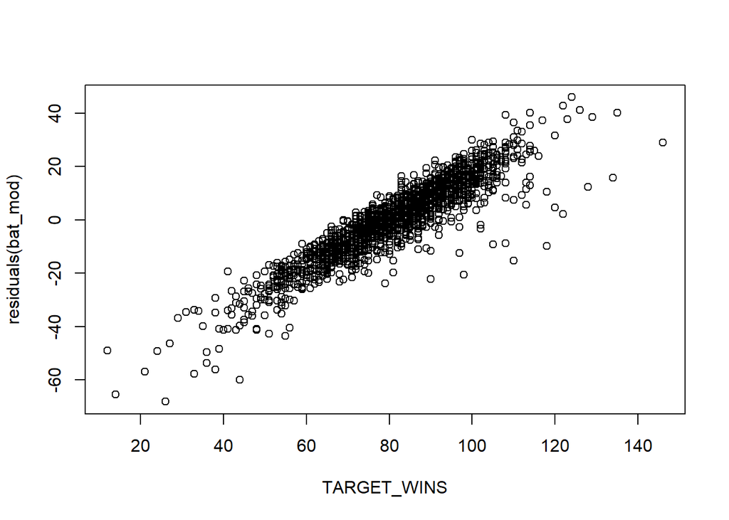

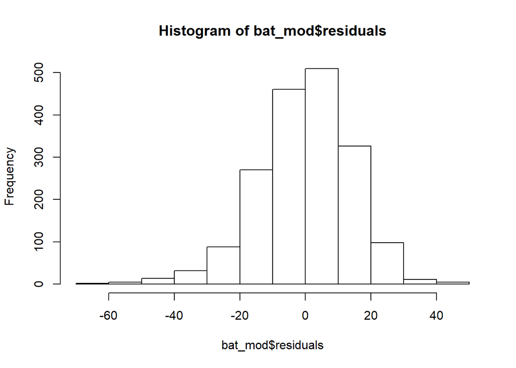

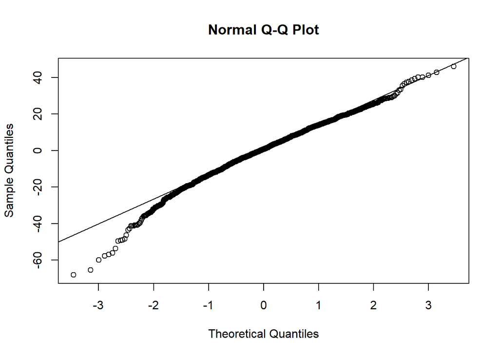

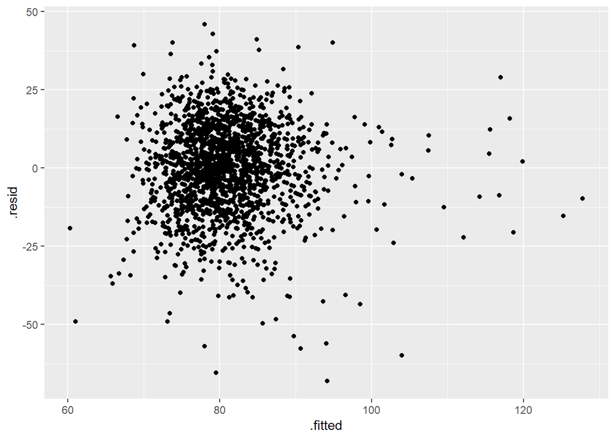